# Principles of Spatial Scale, Part 2

M. Kolak, Center for Spatial Data Science

West Virginia Coal Mining Spatial Analysis: Tract-Level Variations

## Environment Setup

For this lab, you’ll need to have R and RStudio downloaded on your system. You should be able to install packages, and have very basic familiarity with R following intro-level tutorials provided through installation guides. You should also know how to find the address to a folder on your computer system.

# Cookbook

In this practical, we will continue to explore how coal mining impacts West Virginia in a contemporary context. Extending from our work last week (ie. exploring county-level variations), this week’s objectives will be to:

- learn some basics of R to make a more efficient analysis
- work with Census data, and learn to automate some data pulling
- compare mining employment proxies between sources
- compare data at the tract vs county level

## Compare mining employment proxies

The mining data we used last week indicated exact counts of employees working within the coal mining industry and the county level. If we wanted to find similar data using the Census, the closest variable available would be Mining jobs as part of the category “Agriculture, forestry, fishing and hunting, and mining” at the county or tract level within the US Census American Community Survey (ACS 5-year estimate). Before we explore this data at the tract level, let’s first compare the county-level data between sources: Bureau of Labor Statistics and ACS.

We will first work with Census data provided as a CSV file format, to be joined to the master West Virginia county file we generated last week.

### Working Directory Setup

To do this, we first need to ensure we have a working directory where your code and data deside. Make sure that your R script, CSV file provided, and WV county shapefile are all in the same folder. Identify the address to this folder.

Now we can set up our working directory. Again, this will be the folder on your computer system where you are storing script and data for this lab.

```r
# Set working directory
setwd("~/Desktop/IntroGIS/WVCoalMining/TractAnalysis")
```

## Load Libraries

Before loading our data, we will need to load the required packages. While we can load a CSV using base R capabilities, we need the $sf$ package to load spatial data.

If you have not installed $sf$, do so now. You can uncomment the line of code to install, but then re-comment it so you don’t install the package more than once.

```r
# install.packages("sf")
library(sf)
```

## Load Data

Next, load the census data and read in the shapefile of your counties file.

```r
# Load new census data you plan to join.
Census.Data <-read.csv("ACS_15_5YR_DP03.csv")

# Load the output area shapefiles
County.Areas<- st_read("WV_Counties.shp")
```

## View Data

We can quickly view the attributes. One way is to use the “glimpse” function.

```r
# View the attributes associated with each county
glimpse(County.Areas)
```

```
Observations: 55
Variables: 47
$ FIPSSTCO   <fct> 54109, 54107, 54105, 54103, 54101, 54099, 54097, 54095, 5…
$ STATE      <fct> West Virginia, West Virginia, West Virginia, West Virgini…
$ COUNTY     <fct> Wyoming, Wood, Wirt, Wetzel, Webster, Wayne, Upshur, Tyle…
$ POP2000    <int> 25708, 87986, 5873, 17693, 9719, 42903, 23404, 9592, 7321…
$ WHITE      <int> 25345, 85627, 5788, 17502, 9639, 42382, 22981, 9530, 7237…
$ BLACK      <int> 161, 887, 17, 15, 1, 54, 144, 2, 5, 134, 280, 34, 14, 302…
$ AMERI_ES   <int> 31, 188, 12, 17, 7, 99, 39, 5, 14, 31, 33, 32, 28, 46, 14…
$ ASIAN      <int> 21, 448, 6, 57, 6, 86, 72, 8, 1, 27, 12, 35, 13, 106, 568…
$ HAWN_PI    <int> 0, 35, 0, 4, 1, 8, 3, 1, 9, 6, 5, 0, 0, 4, 13, 11, 5, 0, …
$ OTHER      <int> 19, 124, 6, 5, 1, 35, 30, 3, 7, 10, 13, 29, 11, 45, 99, 6…
$ MULT_RACE  <int> 131, 677, 44, 93, 64, 239, 135, 43, 48, 102, 103, 93, 71,…
$ HISPANIC   <int> 135, 514, 18, 74, 36, 202, 137, 41, 18, 95, 71, 104, 49, …
$ MALES      <int> 12649, 42246, 2939, 8586, 4783, 20993, 11354, 4686, 3570,…
```

[output cut: 34 more lines]

```r
# View the attributes associated with each county
head(Census.Data)
```

If we want to see the dimensions of the data, we can use the dim() function. I also like the str() function as it gives an overview of what time of data we have frmo a data structure perspective. I comment out the str() function here as it generates a very long output, but please try for yourself!

From either of these we can see that there 55 observations, or counties, in the dataset. There are 551 variables… In other words, 55 rows x 551 columns.

```r
# View the attributes associated with each county
dim(Census.Data)
```

```
[1]  55 551
```

```r
#str(Census.Data)
```

This Census data – a raw file from the Selected Economic Characteristics ACS 5-year summary profile – has a lot of data, and a lot of variables. To work with this we need to know exactly what variabes we need. You would need the metadata document that comes with the Census profile to identify that. In this lab, I will tell you which variables we’re interested in.

In other words, we need to generate a subset of the raw Census file to include the County geographic identifier, plus rename the key variables of interest.

```r
# Let's further subset the data to make a new, cleaner dataset.
# To uncomplicate things, let's extract data from the original census.
head(Census.Data)
```

|  | GEO.id | GEO.id2 | GEO.display.label | HC01_VC03 | HC02_VC03 | HC03_VC03 | HC04_VC03 | HC01_VC04 | HC02_VC04 | HC03_VC04 | HC04_VC04 | HC01_VC05 | HC02_VC05 | HC03_VC05 | HC04_VC05 | HC01_VC06 | HC02_VC06 | HC03_VC06 | HC04_VC06 | HC01_VC07 | HC02_VC07 | HC03_VC07 | HC04_VC07 | HC01_VC08 | HC02_VC08 | HC03_VC08 | HC04_VC08 | HC01_VC09 | HC02_VC09 | … |
| --- | --- | --- | --- | --- | --- | --- | --- | --- | --- | --- | --- | --- | --- | --- | --- | --- | --- | --- | --- | --- | --- | --- | --- | --- | --- | --- | --- | --- | --- | --- |
| 1 | 0500000US54001 | 54001 | Barbour County, West Virginia | 13634 | 104 | 13634 | NA | 6976 | 293 | 51.2 | 2.2 | 6976 | 293 | 51.2 | 2.2 | 6345 | 338 | 46.5 | 2.5 | 631 | 177 | 4.6 | 1.3 | 0 | 17 | 0.0 | 0.2 | 6658 | 306 | … |
| 2 | 0500000US54003 | 54003 | Berkeley County, West Virginia | 85021 | 249 | 85021 | NA | 55500 | 971 | 65.3 | 1.1 | 55320 | 998 | 65.1 | 1.1 | 49941 | 1017 | 58.7 | 1.2 | 5379 | 593 | 6.3 | 0.7 | 180 | 108 | 0.2 | 0.1 | 29521 | 936 | … |
| 3 | 0500000US54005 | 54005 | Boone County, West Virginia | 19223 | 83 | 19223 | NA | 8360 | 433 | 43.5 | 2.3 | 8360 | 433 | 43.5 | 2.3 | 7592 | 428 | 39.5 | 2.3 | 768 | 218 | 4.0 | 1.1 | 0 | 20 | 0.0 | 0.1 | 10863 | 456 | … |
| 4 | 0500000US54007 | 54007 | Braxton County, West Virginia | 11925 | 72 | 11925 | NA | 6165 | 305 | 51.7 | 2.5 | 6165 | 305 | 51.7 | 2.5 | 5280 | 346 | 44.3 | 2.9 | 885 | 187 | 7.4 | 1.6 | 0 | 17 | 0.0 | 0.2 | 5760 | 304 | … |
| 5 | 0500000US54009 | 54009 | Brooke County, West Virginia | 19950 | 127 | 19950 | NA | 11087 | 346 | 55.6 | 1.8 | 11074 | 352 | 55.5 | 1.9 | 10360 | 376 | 51.9 | 2.0 | 714 | 174 | 3.6 | 0.9 | 13 | 21 | 0.1 | 0.1 | 8863 | 395 | … |
| 6 | 0500000US54011 | 54011 | Cabell County, West Virginia | 79665 | 212 | 79665 | NA | 43086 | 953 | 54.1 | 1.2 | 43049 | 956 | 54.0 | 1.2 | 40103 | 1018 | 50.3 | 1.3 | 2946 | 364 | 3.7 | 0.5 | 37 | 37 | 0.0 | 0.1 | 36579 | 961 | … |

```r
var <- c("GEO.id2","HC01_VC85","HC03_VC50")
```

We generate a list of variables that we want to keep. Note that “GEO.id2” is the unique code that indicates a county. We will use this as our “key” to merge into our master shapefil.

```r
Census.Subset<- (Census.Data[var])
head(Census.Subset)
```

```r
names(Census.Subset)[2:4]<- c("MedInc15", "AgMnJb15","RtlJb15")
glimpse(Census.Subset)
```

[output not shown]

### Merging clean data to Master Shapefile

Now that you’ve cleaned and named the census data showing our mining proxies, we can merge to our master shapefile.

Note that we are joining using key “FIPSSTCO” from the county shapefile, and “GEO.id2” from the census dataset. Look at the data to make sure it joined correctly.

```r
# Joins data to the shapefile
WV_county <- merge(County.Areas, Census.Subset, by.x="FIPSSTCO", by.y="GEO.id2")
head(WV_county)
```

```
Simple feature collection with 6 features and 49 fields
geometry type:  POLYGON
dimension:      XY
bbox:           xmin: 368368.2 ymin: 4179711 xmax: 773040.2 ymax: 4472141
epsg (SRID):    26917
proj4string:    +proj=utm +zone=17 +ellps=GRS80 +towgs84=0,0,0,0,0,0,0 +units=m +no_defs
  FIPSSTCO         STATE   COUNTY POP2000 WHITE BLACK AMERI_ES ASIAN HAWN_PI
1    54001 West Virginia  Barbour   15557 15147    77      111    40       3
2    54003 West Virginia Berkeley   75905 70392  3558      186   350      17
3    54005 West Virginia    Boone   25535 25160   167       31    18       4
4    54007 West Virginia  Braxton   14702 14411   101       51    16       7
5    54009 West Virginia   Brooke   25447 24913   216       25    87       9
6    54011 West Virginia   Cabell   96784 90370  4150      174   749      38
  OTHER MULT_RACE HISPANIC MALES FEMALES AGE_UNDER5 AGE_5_17 AGE_18_21
1    19       160       73  7646    7911        825     2752       928
```

[output cut: 40 more lines]

Great!

## Mapping in R

There are multiple libraries that exist for mapping in R. We will use $tmap$ and to a lesser extent, $ggplot$ in this lab. Let’s start with $tmap$.

First, we need to add the libraries. Install the libraries if you have not done so.

### Loads packages for mapping

```r
library(tmap)
library(leaflet)
```

For basic mapping in R using $tmap$, you have two functions for each variable you need to map. Obviously the data needs to be the spatial file you’ve generated and loaded into the environment. Our Master spatial file is named “WV_County” in our setting here. To visualize the AgMnJb15 variable (our Census mining proxy) we add this to the tm_fill parameter. This generates a default choropleth map.

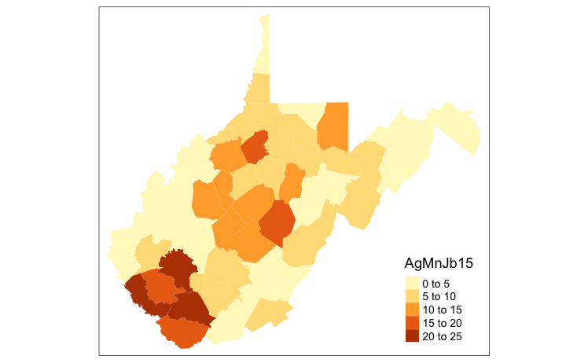

```r
# Creates a simple choropleth map of our a AgMnJb15 variable
tm_shape(WV_county) + tm_fill("AgMnJb15")
```

While this is not a perfect proxy for mining jobs, some of the patterns are consistent with the BLS data source. We can see that majority of jobs in this dataset are in the Southern part of W. Viriginia, in the same area as the highest proportions of coal mining jobs. What areas are less well represented? Why may that be the case?

### Color Palette Options

It is helpful to have a nice range of color palette options when mapping in R. Load the RColorBrewer library and display all the options available to you. Each palette option has a name attached – the is the name that you indicate as a parameter for mapping in $tmap$.

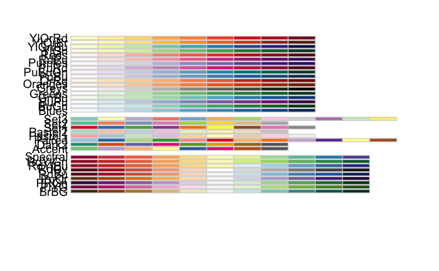

```r
# Display the color palette
library(RColorBrewer)

display.brewer.all()
```

With ColorBrewer, we can switch palettes. If you would like to change the direction of the palette, just add a “negative” sign.

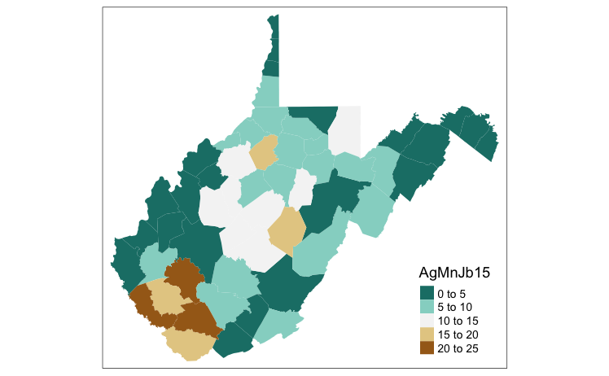

```r
# setting a colour palette
tm_shape(WV_county) + tm_fill("AgMnJb15", palette = "-BrBG")
```

You can also change the data classification interval. It defaults on a “pretty classification” which has been optimized for easy-to-read breaks, but may not reflect the actual data best. To see different parameter options, research the $tmap$ documentation page.

Here we try quantile breaks, and then specific the number of levels or breaks.

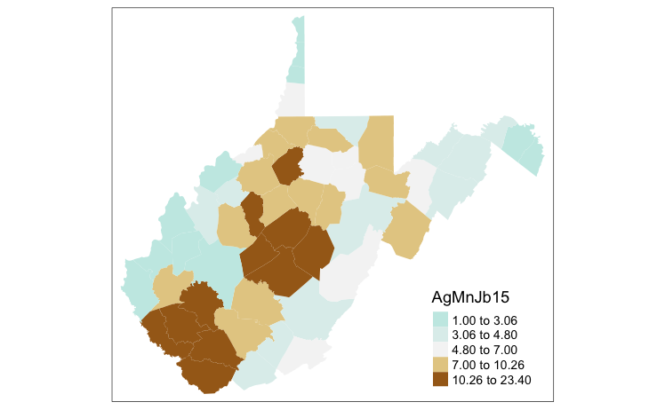

```r
# changing the intervals
tm_shape(WV_county) + tm_fill("AgMnJb15", style = "quantile", palette = "-BrBG")
```

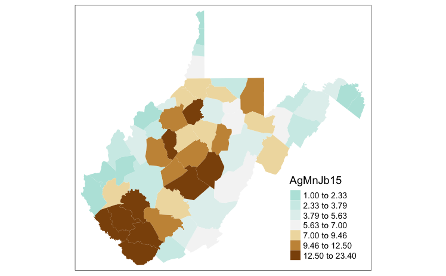

```r
# number of levels
tm_shape(WV_county) + tm_fill("AgMnJb15", style = "quantile", n = 7, palette = "-BrBG")
```

How does this change your interpretation? Try additional parameter specifications like “jenks” for Jenks breaks, or “st” for standard deviation breaks.

### Map Customization using tmap

There are multiple other options when designing maps using tmap. Many of these are best optimized for generating in an R script directly, rather than in an R Markdown, as RStudio can enforce odd behaviors when it doesn’t have full space to generate plots. Take the following code as examples for what you should try in your own RStudio environment within an R script (rather than an RMarkdown file).

Finally, experiment with the parameters here, and continue to explore the tmap documentation. (Google search terms: “tmap R” to get information directly.)

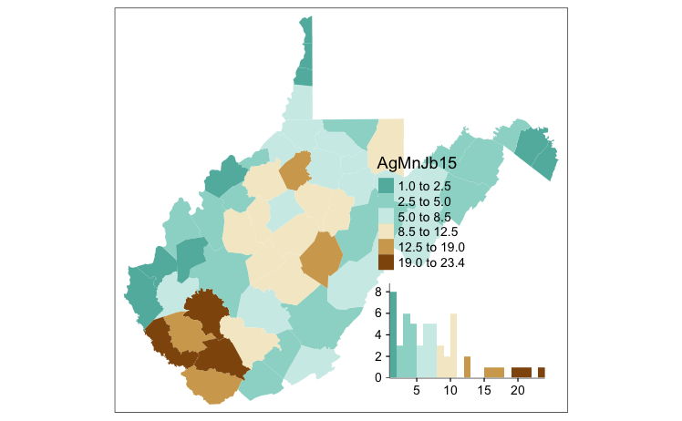

```r
# includes a histogram in the legend
tm_shape(WV_county) + tm_fill("AgMnJb15", style = "jenks", n=6, palette = "-BrBG", legend.hist = TRUE)
```

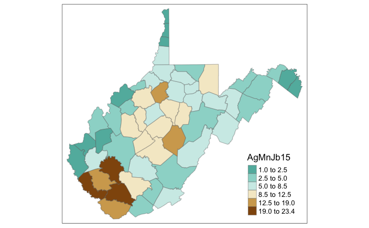

```r
# add borders
tm_shape(WV_county) + tm_fill("AgMnJb15", style = "jenks", n=6, palette = "-BrBG") +
  tm_borders(alpha=.4)
```

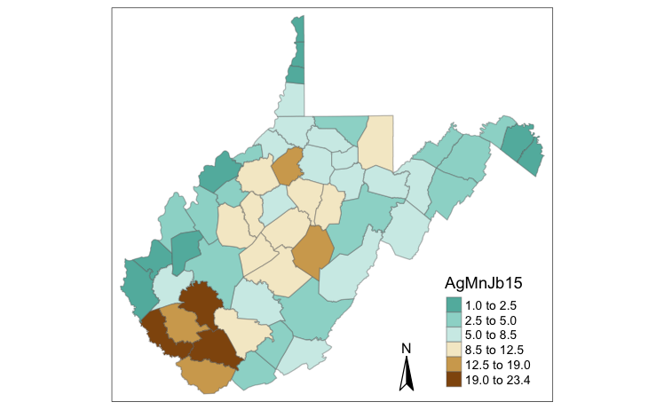

```r
# north arrow
tm_shape(WV_county) + tm_fill("AgMnJb15", style = "jenks", n=6, palette = "-BrBG") +
  tm_borders(alpha=.4) +
  tm_compass()
```

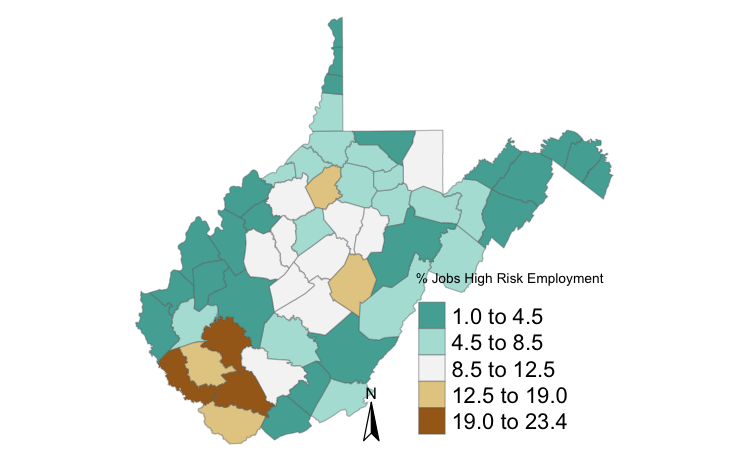

```r
# adds in layout, gets rid of frame
tm_shape(WV_county) + tm_fill("AgMnJb15", palette = "-BrBG", style = "jenks", title = "% Jobs High Risk Employment") +
  tm_borders(alpha=.4) +
  tm_compass() +
  tm_layout(legend.text.size = 1.1, legend.title.size = 1.5, legend.position = c("right", "bottom"), frame = FALSE)
```

## Comparing Data Sources

Now that we have a Master spatial dataset that includes both proxies, we can compare the mining data proxies. How close is the mining proxy data from the Census to the actual mining employment numbers from BLS?

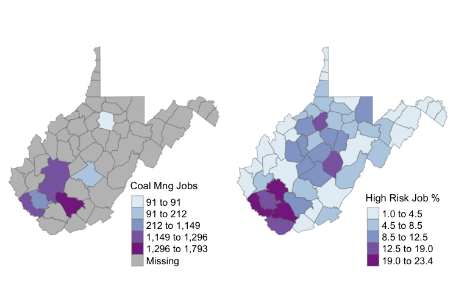

```r
# ReMap
BLSData <- tm_shape(WV_county) + tm_fill("AveEmp15", palette = "BuPu", style = "jenks", title = "Coal Mng Jobs") +
  tm_borders(alpha=.4) +
  tm_layout(legend.text.size = .8, legend.title.size = 1.0, legend.position = c("right", "bottom"), frame = FALSE)

ACSData <- tm_shape(WV_county) + tm_fill("AgMnJb15", palette = "BuPu", style = "jenks", title = "High Risk Job %") +
  tm_borders(alpha=.4) +
  tm_layout(legend.text.size = .8, legend.title.size = 1.0, legend.position = c("right", "bottom"), frame = FALSE)

tmap_arrange(BLSData,ACSData)
```

Here’s another way to generate the maps side by side:

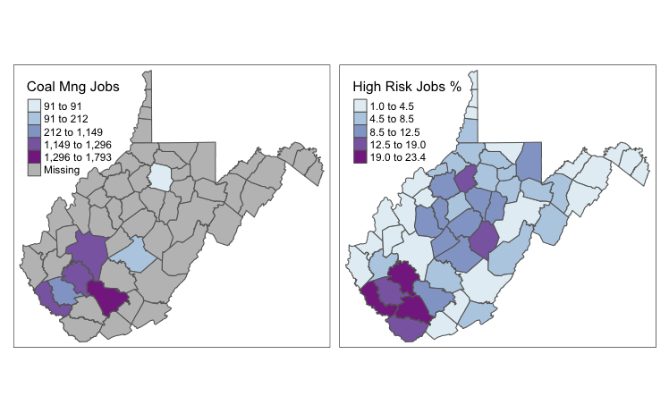

```r
# Another Route:
tm_shape(WV_county) +
  tm_polygons(c("AveEmp15", "AgMnJb15"),
              style=c("jenks", "jenks"),
              palette=list("BuPu", "BuPu"),
              title=c("Coal Mng Jobs", "High Risk Jobs %")) +
  tm_facets(ncol=2)
```

Obviously the ACS data is overestimating in some areas, and undestimating in others. While it captures the increase in mining jobs in the Southermost area, it misses the county with the highest mining jobs when considering all the other employment categories included. Getting finer resolution data for coal mining below county may not be available, but at least we know relatively how useful this Census category is.

## Working with Census Data using tidycensus

In this lab I provided the raw data to you for 2015 that you wrangled and cleaned.  
Another excellent option in R coding environments is using a package to extract Census data for you. While you won’t be able to access all the data the same way, for some of the “classic” indicators like population demographics and income, using the Census API is the most efficient approach.

Let’s extract median income for WV counties and census tracts to see if we gain any insight into our analysis.

### Load libraries

```r
library(tidyverse)
library(tidycensus)
options(tigris_use_cache = TRUE)
```

### Getting and activiting your Census API key

To work with tidycensus, you must first register for and activate your Census API key. Follow the instructions here.

Add your API Key. This should be done in your console or your personal file; the API key should not be shared. I include dummy code below that has been commented out. For my implementation to work, I needed to add two additional parameters after simple debugging.

```r
#census_api_key("YOURAPIKEY", install=TRUE, overwrite = TRUE)
```

Using the documentation for tidycensus by Kyle Walker, we first load variables from the ACS 5-year estimated for 2015 (so from years 2011-2015). The “view” option opens a window in your RStudio environment where you can explore the Census variables available to you in detail. This is how you can find the definitions of the variables of interest, using the search functionality availble in RStudio. See the Kyle Walker demo for more specifics.

```r
ACS15var <- load_variables(2015, "acs5", cache = TRUE)
view(ACS14var)
```

```
Error in enquo(expr) : object 'ACS14var' not found
```

Next we can extract the exact data. This functions gathers data for median income levels for all counties in West Virginia, using the 2015 dataset.

The logic used here is from “tidyverse” – we don’t talk about that in detail in the course, but recommend researching that on your own for your interest.

```r
WV_county_medinc <- get_acs(geography = "county",
              variables = c(medincome = "B19013_001"),
              state = "WV",
              year = 2015)
```

```
Error in curl::curl_fetch_memory(url, handle = handle) :
  Operation was aborted by an application callback
```

The latest editino of tidycensus adds the ability to extract the attribute data with the spatial data itself. In this function, we extract the same data but actually pull the county shapes as well. The object is thus a spatial file, not a simple data file.

```r
WV_county_medinc.sp <- get_acs(state = "WV",
                     geography = "county",
                     variables = "B19013_001",
                     geometry = TRUE)
head(WV_county_medinc.sp)
```

```
Simple feature collection with 6 features and 5 fields
geometry type:  MULTIPOLYGON
dimension:      XY
bbox:           xmin: -82.50768 ymin: 37.76331 xmax: -77.82356 ymax: 40.39976
epsg (SRID):    4269
proj4string:    +proj=longlat +ellps=GRS80 +towgs84=0,0,0,0,0,0,0 +no_defs
  GEOID                           NAME   variable estimate  moe
1 54001  Barbour County, West Virginia B19013_001    39580 4632
2 54003 Berkeley County, West Virginia B19013_001    60615 1882
3 54005    Boone County, West Virginia B19013_001    38642 3787
4 54007  Braxton County, West Virginia B19013_001    42213 5363
5 54009   Brooke County, West Virginia B19013_001    49772 3595
6 54011   Cabell County, West Virginia B19013_001    38321 1341
                        geometry
1 MULTIPOLYGON (((-80.22631 3...
2 MULTIPOLYGON (((-78.22901 3...
3 MULTIPOLYGON (((-81.97956 3...
4 MULTIPOLYGON (((-80.98495 3...
5 MULTIPOLYGON (((-80.6796 40...
6 MULTIPOLYGON (((-82.50768 3...
```

Using the tidycensus tutorial, you can quickly plot the data using $ggplot$.

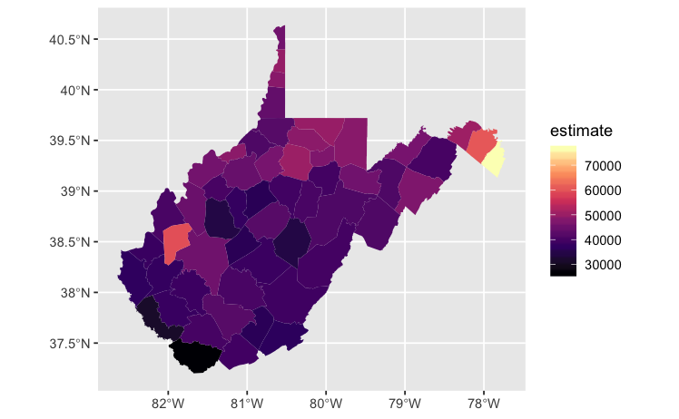

```r
WV_county_medinc.sp %>%
  ggplot(aes(fill = estimate)) +
  geom_sf(color = NA) +
  scale_fill_viridis_c(option = "magma")
```

Of course, you can also plot using tmap. Note that the variable of interest is called “estimate” here, using the tidycensus default. I recommend just working with one attribute at a time when first working with tidycensus and R.

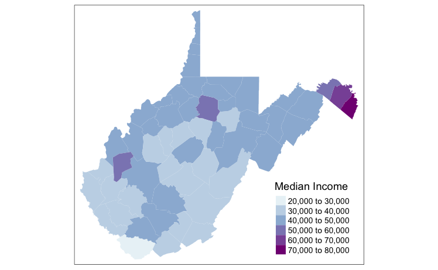

```r
tm_shape(WV_county_medinc.sp) + tm_fill("estimate", palette = "BuPu", title ="Median Income")
```

What’s nice about tidycensus is that we can quickly run the same function to get the spatial data at a different resolution. Here we can gather median income information at the tract level.

```r
WV_tracts_medinc.sp <- get_acs(state = "WV",
                     geography = "tract",
                     variables = "B19013_001",
                     geometry = TRUE)
head(WV_tracts_medinc.sp)
```

```
Simple feature collection with 6 features and 5 fields
geometry type:  MULTIPOLYGON
dimension:      XY
bbox:           xmin: -80.22717 ymin: 38.94724 xmax: -77.82975 ymax: 39.61915
epsg (SRID):    4269
proj4string:    +proj=longlat +ellps=GRS80 +towgs84=0,0,0,0,0,0,0 +no_defs
        GEOID                                                 NAME   variable
1 54001965500     Census Tract 9655, Barbour County, West Virginia B19013_001
2 54001965600     Census Tract 9656, Barbour County, West Virginia B19013_001
3 54001965700     Census Tract 9657, Barbour County, West Virginia B19013_001
4 54001965800     Census Tract 9658, Barbour County, West Virginia B19013_001
5 54003971101 Census Tract 9711.01, Berkeley County, West Virginia B19013_001
6 54003971102 Census Tract 9711.02, Berkeley County, West Virginia B19013_001
  estimate   moe                       geometry
1    47092  5751 MULTIPOLYGON (((-80.22631 3...
2    26429  8650 MULTIPOLYGON (((-80.10631 3...
3    41029 11601 MULTIPOLYGON (((-80.07606 3...
4    33929  8376 MULTIPOLYGON (((-79.98156 3...
5    58643 14597 MULTIPOLYGON (((-77.92404 3...
6    66392 10805 MULTIPOLYGON (((-77.9613 39...
```

Next, we can plot it using both ggplot and tmap.

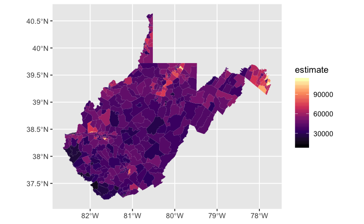

```r
WV_tracts_medinc.sp %>%
  ggplot(aes(fill = estimate)) +
  geom_sf(color = NA) +
  scale_fill_viridis_c(option = "magma")
```

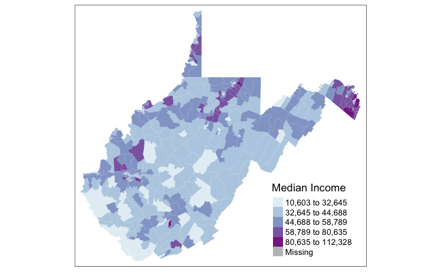

```r
tm_shape(WV_tracts_medinc.sp) + tm_fill("estimate", style = "jenks", palette = "BuPu", title ="Median Income")
```

What new insights did you find?

### What about the Scale of Coal Mining in WV?

Finally – so about the scale of coal mining in West Virginia? While we know the ACS data is an imperfect represetnation of coal mining the state, we also know it captures some of the higher proportions of mining employment, especially in the Southern part of the state.

Thus, let’s map this variable at County and Tract scales to look for some patterns.

First, we extract the data:

```r
WV_county_mining.sp <- get_acs(state = "WV",
                     geography = "county",
                     variables = "B24031_002",
                     geometry = TRUE)
WV_tracts_mining.sp <- get_acs(state = "WV",
                     geography = "tract",
                     variables = "B24031_002",
                     geometry = TRUE)
```

Next, we map both side by side:

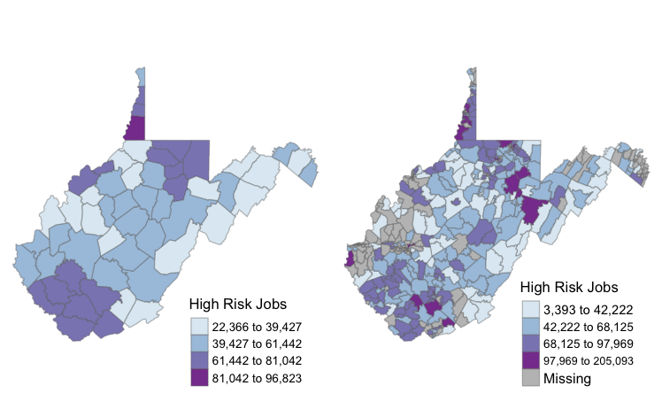

```r
# ReMap
WVCounties <- tm_shape(WV_county_mining.sp) + tm_fill("estimate", n=4, palette = "BuPu", style = "jenks", title = "High Risk Jobs") +
  tm_borders(alpha=.4) +
  tm_layout(legend.text.size = .8, legend.title.size = 1.0, legend.position = c("right", "bottom"), frame = FALSE)

WVTracts <- tm_shape(WV_tracts_mining.sp) + tm_fill("estimate", n=4, palette = "BuPu", style = "jenks", title = "High Risk Jobs") +
  tm_borders(alpha=.4) +
  tm_layout(legend.text.size = .8, legend.title.size = 1.0, legend.position = c("right", "bottom"), frame = FALSE)

tmap_arrange(WVCounties,WVTracts)
```

### Interpretation

What type of variation do you find between these maps? Knowing that there is more connection with mining in th Southern area, were you suprised by the variation below the county level? At what scale is coal mining employment occurring? Broadening to a wider “High Risk Employment” category for jobs that are more prone to accidents (including construction, mining, agricultural, etc) captured in this Census variable, what additional insights might you have?

Note that this variable is sometimes used for identifying areas at risk for opioid overdose. If some jobs are more prone to injury, then workers could also be more prone to getting prescription opioids for pain management, a component of the opioid epidemic. At the same time, these areas often have few other job options. When high-paying coal mining jobs go away (“high” relative to median income in the area), there may not be other options that promise the same pay and/or stability. This “economics of despair” concept likewise is thought the drive increases in opioid-related overdoses. Consider the complexity here – and how might you further detangle these concepts?

### Accessing Census Data

While the tidycensus package is great for straightforward variables like income level, it may not always be for all variables. For example, if we search for “mining” in the existing View only a small selection is returned. We could for example try variable “B08126_002” corresponding to the total estimate of persons in Agriculture, forestry, fishing and hunting, and mining industries, but this is not the percentage of the workforce in these industries (which would be more precise). Rather than calculate this on our own (which also needs to account for the total able-to-work population), it’s more efficient to use pre-calculated Census metrics.

I thus recommend that for more detailed Census explorations, you take the time to get familiar with various Census data profiles. For example, the DP03 data profile of the American Community Survey with selected economic characteristics is especially useful for our purposes here.

For your own research, I recommend investigating IPUMS and the new Data.gov site that releases more detailed Census profiles with ther required metadata components. The previous version, American Factfinder, has been retired.

### Saving your Master spatial file

After all the hard work in this analysis, you’ll want to save the master files you generated. The “st_write” function saves the spatial file as a shapefile. For example you can save the county file you updated earlier. The file is save to your working directory.

```r
st_write(WV_county, "WV_county.shp")
```